# Final Report - Data Science

## Bachelor in Computer Science / PUCPR

Professor Jean Paul Barddal

André Mayer Tomazoni - andremayer2000@gmail.com

Henrique Olivo Antonio - henriqueolivoantonio@outlook.com

Matheus Henrique de Oliveira - gaiake12@hotmail.com

Vitor Luis Kubiak da Silva - vitor.lll@hotmail.com

2020

# Import the libs you need

```python
# Import all packages you need here
import pandas as pd
import numpy as np
import matplotlib.pyplot as plt
import seaborn as sns
```

# Loading your data

Below, load the data using pandas and make all the necessary data cleansing so that all data types are correct for posterior analysis.

```python
# load your data here
from google.colab import drive
drive.mount('/content/drive', force_remount=True)

train_dataset = pd.read_csv('/content/drive/My Drive/train.csv', na_values=-9999)
test_dataset = pd.read_csv('/content/drive/My Drive/test.csv', na_values=-9999)
```

```python
# clean and treat the data here
train_dataset.head(4)
```

|  | HS_CPF | TEMPOCPF | DISTCENTROCIDADE | ORIENTACAO_SEXUAL | RELIGIAO | DISTZONARISCO | QTDENDERECO | QTDEMAIL | QTDCELULAR | CELULARPROCON | QTDFONEFIXO | TELFIXOPROCON | INDICEEMPREGO | PORTEEMPREGADOR | SOCIOEMPRESA | FUNCIONARIOPUBLICO | SEGMENTACAO | SEGMENTACAOCOBRANCA | SEGMENTACAOECOM | SEGMENTACAOFIN | SEGMENTACAOTELECOM | QTDPESSOASCASA | MENORRENDACASA | MAIORRENDACASA | SOMARENDACASA | MEDIARENDACASA | MAIORIDADECASA | MENORIDADECASA | MEDIAIDADECASA | … |
| --- | --- | --- | --- | --- | --- | --- | --- | --- | --- | --- | --- | --- | --- | --- | --- | --- | --- | --- | --- | --- | --- | --- | --- | --- | --- | --- | --- | --- | --- | --- |
| 0 | 4089 | 20.314066 | -0.530710 | HETERO | EVANGELICA | 133904.875225 | 0.225217 | -0.623978 | 1.254827 | 0.0 | 1.359449 | 0.0 | 0.0 | 0.0 | 0.0 | 0.0 | 0.0 | 0.0 | 0.0 | 0.0 | 0.0 | 2.0 | 400.571379 | 900.163987 | 1300.05235 | 649.320855 | 37.930754 | 8.971543 | 23.326428 | … |
| 1 | 505275 | 27.453985 | 2210.462581 | HETERO | CATOLICA | 171360.245998 | 0.763194 | 1.831920 | 3.414313 | 0.0 | 2.601777 | 0.0 | 0.0 | 0.0 | 0.0 | 0.0 | 1.0 | 0.0 | 0.0 | 1.0 | 0.0 | NaN | NaN | NaN | NaN | NaN | NaN | NaN | NaN | … |
| 2 | 87104 | 10.251913 | -0.482789 | HETERO | CATOLICA | 153737.268091 | 1.231079 | -1.234011 | 3.309840 | 0.0 | 1.435696 | 0.0 | 4.0 | 1.0 | 0.0 | 0.0 | 1.0 | 0.0 | 0.0 | 1.0 | 0.0 | NaN | NaN | NaN | NaN | NaN | NaN | NaN | NaN | … |
| 3 | 173070 | 26.325559 | 3162.427014 | HETERO | EVANGELICA | 225.740504 | 2.309775 | 0.093034 | 0.980513 | 0.0 | 1.709005 | 0.0 | 0.0 | 0.0 | 1.0 | 0.0 | 3.0 | 0.0 | 1.0 | 0.0 | 3.0 | NaN | NaN | NaN | NaN | NaN | NaN | NaN | NaN | … |

```python
# Remove LGPD non permitted
train_dataset = train_dataset.drop(columns=['ORIENTACAO_SEXUAL', 'RELIGIAO'], axis=1)
```

```python
# filtering lower than 0
listColumnsChangeGTZ = ['IDHMUNICIPIO', 'QTDAUTOMOVELMUNICIPIO', 'TEMPOCPF', 'QTDFONEFIXO', 'QTDCELULAR', 'QTDENDERECO', 'DISTCENTROCIDADE', 'DISTZONARISCO', 'QTDEMAIL', 'MENORRENDACASA', 'MAIORRENDACASA', 'MEDIARENDACASA', 'MAIORIDADECASA', 'MENORIDADECASA', 'IDADEMEDIACEP', 'PERCENTMASCCEP', 'PERCENTFEMCEP', 'PERCENTPRIMARIOCEP', 'PERCENTFUNDAMENTALCEP', 'PERCENTMEDIOCEP', 'PERCENTSUPERIORCEP', 'PERCENTMESTRADOCEP', 'PERCENTDOUTORADOCEP', 'PERCENTBOLSAFAMILIACEP', 'PERCENTFUNCIONARIOPUBLICOCEP', 'MEDIARENDACEP', 'PIBMUNICIPIO', 'PERCENTPOPZONAURBANA', 'IDHMUNICIPIO', 'ESTIMATIVARENDA', 'QTDDECLARACAOISENTA', 'QTDDECLARACAO10', 'QTDDECLARACAOREST10', 'QTDDECLARACAOPAGAR10']
for column in listColumnsChangeGTZ:
  train_dataset[column][train_dataset[column] < 0] = np.nan

# changing break float to floor
listColumnsChangeFloor = ['BOLSAFAMILIA','SOCIOEMPRESA','FUNCIONARIOPUBLICO', 'FUNCIONARIOPUBLICOCASA', 'QTDENDERECO', 'QTDEMAIL', 'QTDCELULAR', 'QTDFONEFIXO', 'QTDUTILITARIOMUNICIPIO', 'QTDAUTOMOVELMUNICIPIO', 'QTDCAMINHAOMUNICIPIO', 'QTDCAMINHONETEMUNICIPIO', 'QTDMOTOMUNICIPIO', 'BOLSAFAMILIA', 'FUNCIONARIOPUBLICO']
for column in listColumnsChangeFloor:
  train_dataset[column] = np.floor(train_dataset[column])
```

```python
train_dataset['IDHMUNICIPIO'].unique().min()
```

```
nan
```

# Univariate data analysis

In this section, you should perform univariate data analysis on at least 20 variables.

In the end, you should describe the main variables that are of your interest, and these should be accounted for in the next sections of the report. The definition of each variable chosen should be clarified, so arbitrary selections are **not** accepted at this point.

For each variable plotted, make sure you determine the following:

1. The distribution of the data (gaussian, binomial, exponential, etc)
2. Skew
3. Kurtosis
4. Mean, standard deviation, and what they stand for in the context of the dataset

Regardless of the type of the variable being analyzed, make sure you plot it correctly. For instance, make sure scatterplots are not used for categorical data and so forth.

```python
# place as many cells to plot the visualizations,
# as well as to describe the main findings

def univariableDetails(univariable, variableType='numeric'):
  def modeAdaption(npArray):
    primary = npArray[0]
    secondary = npArray[1]

    if primary == secondary:
      return False
    return primary

  skew = ''
  kurtosis = ''

  mode = modeAdaption(univariable.value_counts().values)
  mean = univariable.mean()
  median = univariable.median()

  if (mode == mean and mean == median):
    skew = 'Symmetric'
  if (mode < mean > median):
    skew = 'Positive assymetry'
  if (mode > mean < median):
    skew = 'Negative assymetry'


  kurt = univariable.kurt()

  if (kurt > 0):
    kurtosis = 'Leptokurtic'
  elif (kurt < 0):
    kurtosis = 'Platykurtic'
  else:
    kurtosis = 'Mesokurtic'

  print('Kurtosis', kurtosis)
  print('Skew:', skew)
  print('Mode:', mode)
  print('Mean:', mean)
  print('Median:', median)

  sns.distplot(univariable)
  plt.show()

  if variableType == 'numeric':
    univariable.hist(bins=25)
    plt.show()

    sns.boxplot(univariable)
    plt.show()

  else:
    sns.countplot(univariable)
    plt.show()
```

### Tempo CPF

> Representa em anos quanto tempo o CPF existe.

```
Kurtosis Platykurtic
Skew: Positive assymetry
Mode: False
Mean: 15.737885746529088
Median: 15.182564848358659
```

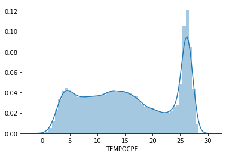

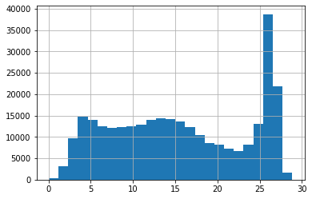

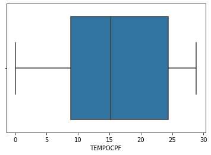

```
-1.3293084192221831
```

```python
univariableDetails(train_dataset['TEMPOCPF'])
train_dataset['TEMPOCPF'].kurt()
```

### QTDPESSOASCASA

> Representa quantas pessoas moram na mesma casa.

```
Kurtosis Leptokurtic
Skew: Negative assymetry
Mode: 50850
Mean: 2.994602250645571
Median: 3.0
```

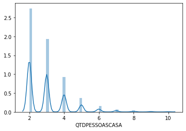

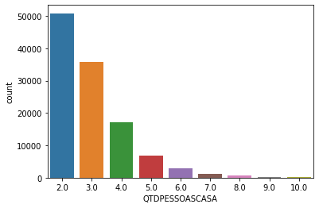

```python
univariableDetails(train_dataset['QTDPESSOASCASA'], 'categorical')
```

### MAIORRENDACASA

> Representa a maior renda da casa.

```
Kurtosis Leptokurtic
Skew: Positive assymetry
Mode: False
Mean: 5260.921456091744
Median: 2999.8417294960136
```

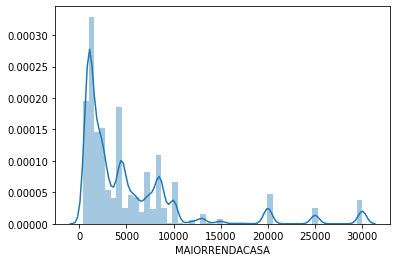

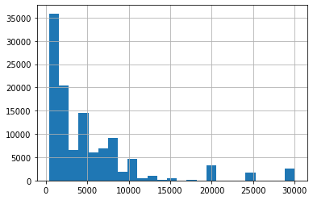

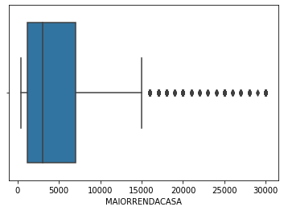

```python
univariableDetails(train_dataset['MAIORRENDACASA'])
```

### QTDCELULAR

> Representa a quantidade de celular percentencentes a uma pessoa.

```
Kurtosis Leptokurtic
Skew: Negative assymetry
Mode: 112286
Mean: 0.8991169977924944
Median: 1.0
```

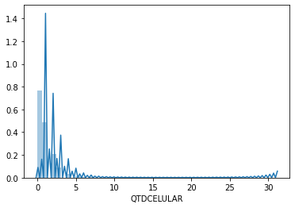

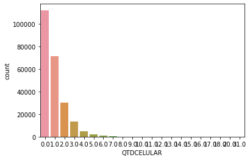

```python
univariableDetails(train_dataset['QTDCELULAR'], 'categorical')
```

### IDADEMEDIACEP

> Idade média do seu CEP.

```
Kurtosis Leptokurtic
Skew: Positive assymetry
Mode: False
Mean: 45.65076037715526
Median: 45.51802468414977
```

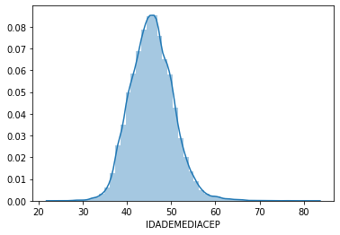

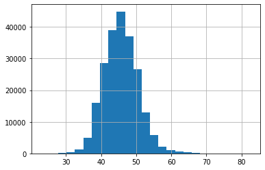

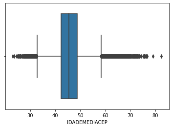

```python
univariableDetails(train_dataset['IDADEMEDIACEP'])
```

### PIBMUNICIPIO

> O PIB do município de uma pessoa.

```
Kurtosis Leptokurtic
Skew: Positive assymetry
Mode: False
Mean: 31347.716175086796
Median: 30952.04735728275
```

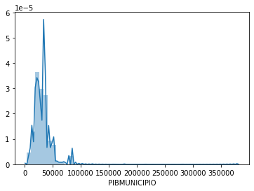

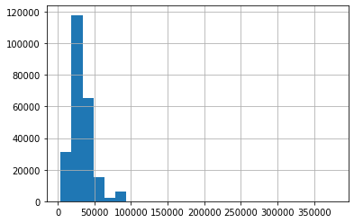

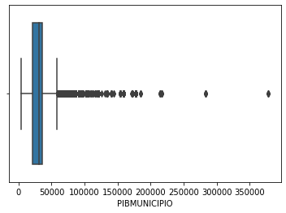

```python
univariableDetails(train_dataset['PIBMUNICIPIO'])
```

### IDHMUNICIPIO

> O IDH do município de uma pessoa.

```
Kurtosis Leptokurtic
Skew:
Mode: False
Mean: 74.68427056629352
Median: 74.76636749275026
```

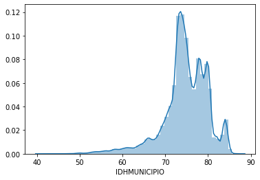

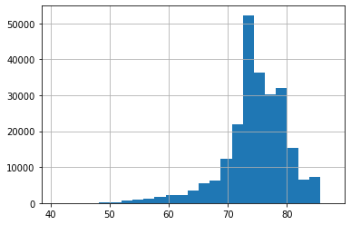

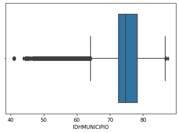

```python
univariableDetails(train_dataset['IDHMUNICIPIO'])
```

### BOLSAFAMILIA

> Se a pessoa tem ou não o bencefício do bolsa família.

```
Kurtosis Leptokurtic
Skew:
Mode: 290762
Mean: 0.041414461104297716
Median: 0.0
```

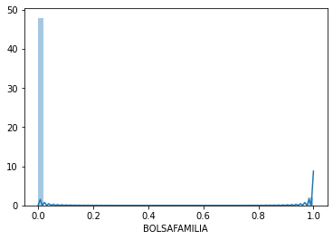

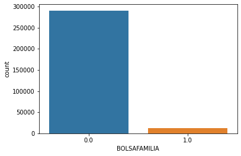

```python
univariableDetails(train_dataset['BOLSAFAMILIA'], 'categorical')
```

### TARGET

> Se a pessoa é adimplente ou inadimplente.

```
Kurtosis Leptokurtic
Skew:
Mode: 277680
Mean: 0.09640847751596937
Median: 0.0
```

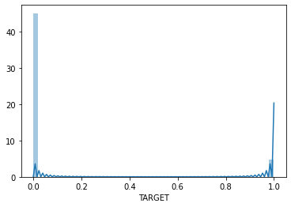

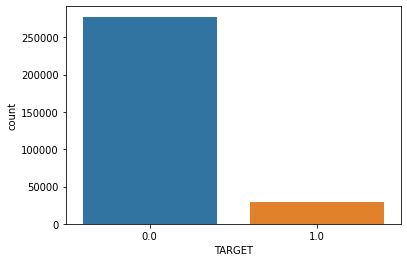

```python
univariableDetails(train_dataset['TARGET'], 'categorical')
```

### DISTZONARISCO

> Qual é a distância da casa da pessoa a uma zona de risco.

```
Kurtosis Leptokurtic
Skew: Positive assymetry
Mode: False
Mean: 82683.46564068593
Median: 4313.584754691626
```

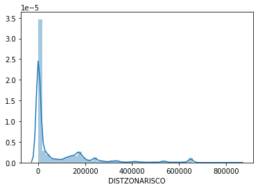

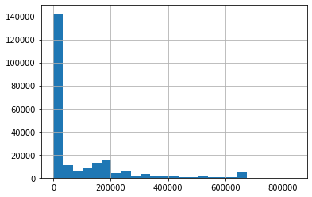

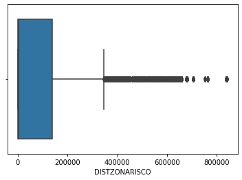

```python
univariableDetails(train_dataset['DISTZONARISCO'])
```

### DISTCENTROCIDADE

> Qual é a distância da casa de uma pessoa até o centro da cidade.

```
Kurtosis Leptokurtic
Skew: Positive assymetry
Mode: False
Mean: 4556.265221645442
Median: 3359.6676568275766
```

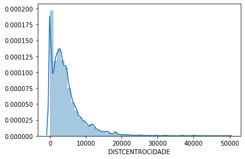

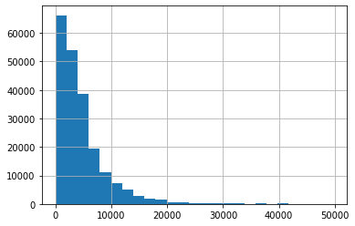

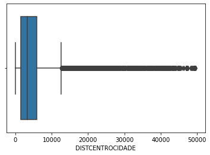

```python
univariableDetails(train_dataset['DISTCENTROCIDADE'])
```